# The Patriot Way

An Exploratory Analysis of the New England Patriots *Almost* Undefeated Season

Cameron Jester

02/16/2022

*This blog post is dedicated to my dad, my favorite person to watch football with.*

# A Spectacular Story

Recently I have been reminiscing on the miraculous, and equally devastating 2007 NFL season, as any committed Patriots fan does. Although I was only 6 years old at the time, and far from the fan I am today, I am told (I refuse to watch the footage) of the horror that occurred on February 3rd, 2008. Nonetheless, the New England Patriots accomplished something that has never been done before, and has yet to be done again (not including the recent addition of week 17): go 16-0 on a season. Now, I am conducting an exploratory analysis on the 2007 New England Patriots and their road to the 2008 Super Bowl.

[figure not shown]

New England Patriots, image source : the ringer.com

### Who Ran the AFC East?

To begin this analysis, it is important to give basic context on the New England Patriots in relation to the rest of the National Football League, which consists of 32 teams across 2 divisions, which are then broken up into 4 separate regions. The Patriots belong to the AFC East, alongside the New York Jets, the Miami Dolphins, and the Buffalo Bills. For simplicity sake, I will compare the Patriots to its AFC East counterparts from 2000-2019 to get the analysis started.

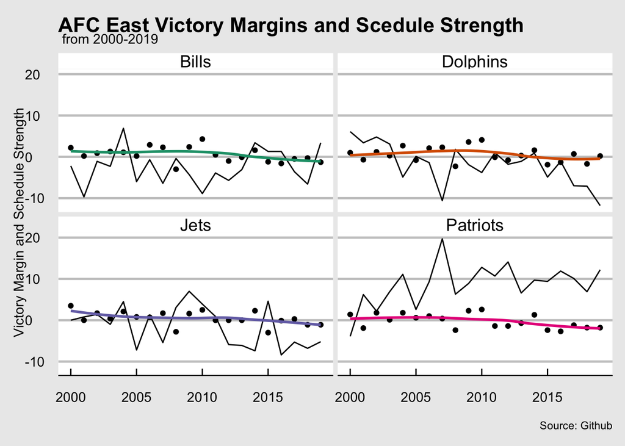

```r
ggplot(data = standings_east, mapping = aes(x = year, y = margin_of_victory)) +
  geom_line() + geom_point(aes(x=year, y = strength_of_schedule))  + geom_smooth(data = standings_east, mapping = aes(x = year, y = strength_of_schedule, color = team_name), se = FALSE)+
  facet_wrap(~ team_name ) + labs (x = "", y = "Victory Margin and Schedule Strength", title = "AFC East Victory Margins and Scedule Strength", subtitle = " from 2000-2019", caption = "Source: Github")  + theme_economist_white()+ theme(legend.position = "none") + scale_color_brewer(palette = "Dark2")
```

The graph above shows the AFC East team’s victory margin and schedule strength from 2000-2019. Victory margins is a measurement of points allowed subtracted by points scored and divided by the number of games played, basically showing a team’s overall victory rating. The sharp peak in the New England Patriots 2007 season is a whopping 19.7 victory margin, the highest of any team across 2000-2019. In fact, over the course of those 19 years, the Patriots had the margins of victory in 12 seasons, but what exactly made the 2007 season special? Maybe it was an outstanding offensive line, with players like Randy Moss or an exquisite defense,home of my favorite player of all-time, Rodney Harrison. Or was it for something less exciting, like an easy schedule? This is getting interesting…lets find out.

### 2007: Patriots Domination

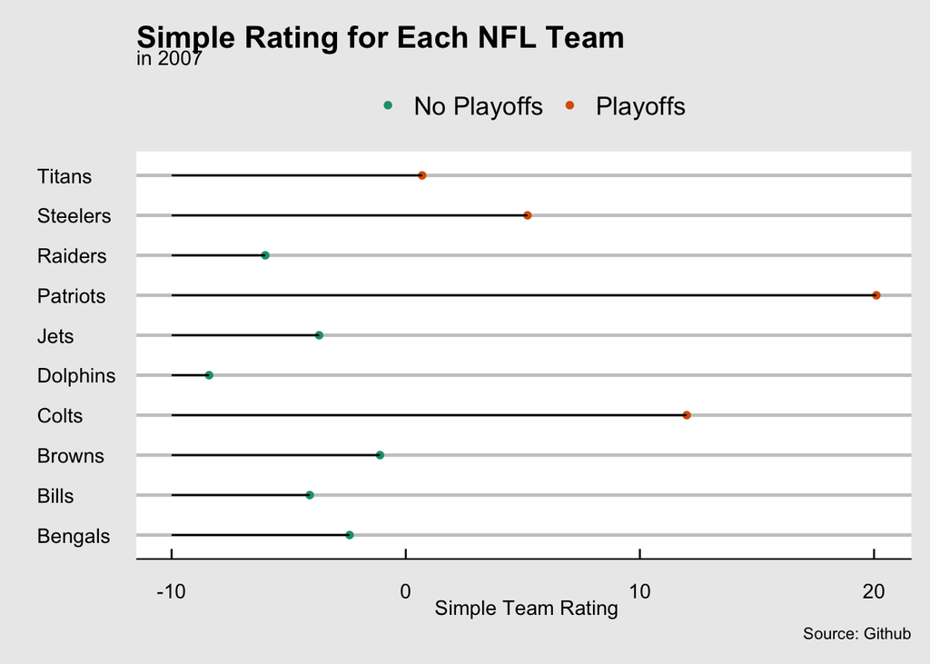

```r
standings%>%
  ggplot(data = standings_2007_AFC, mapping = aes(x = team_name, y = simple_rating)) + geom_point(aes(color = playoffs))  + labs (x = "", y = " Simple Team Rating", caption = "Source: Github") + labs(title = "Simple Rating for Each NFL Team", subtitle = "in 2007", col = "") + theme_economist_white() + coord_flip()   + scale_color_brewer(palette = "Dark2") + geom_segment( aes(x=team_name, xend=team_name, y=-10, yend=simple_rating))
```

The graph above shows the ‘Simple Team Rating’ for AFC teams in 2007. “Simple Team Rating’ or SRS is a scale used across a variety sports and is calculated using a *slightly* complicated algorithm (SRS = MoV + SoS = ORRS + DSRS). For now, just think of the SRS as a cumulative”grade" given to a team based on their schedule strength, opponent rating, point differentials, wins/losses, etc.

In the 2007 season the Patriots had an outstanding SRS of 20.1, which is a 8.1 lead on the next highest team, the Indianapolis Colts. Shockingly, 21 teams had a negative SRS, I certainly wouldn’t have wanted to be a fan of any of those teams in 2007, especially the St. Louis Rams (now the Los Angelas Rams) who had a measily -13 rating.

The Patriots Simple Rating Score of 20.1 was a culmination of their offensive rating of 15.9 (highest in the league) and a defensive rating of 4.2 (sixth in the league). So the New England Patriots had the best offense in the league in 2007, how did that get help them become the only team in NFL history to go 16-0 in a season?

### An Offense Story for the Ages

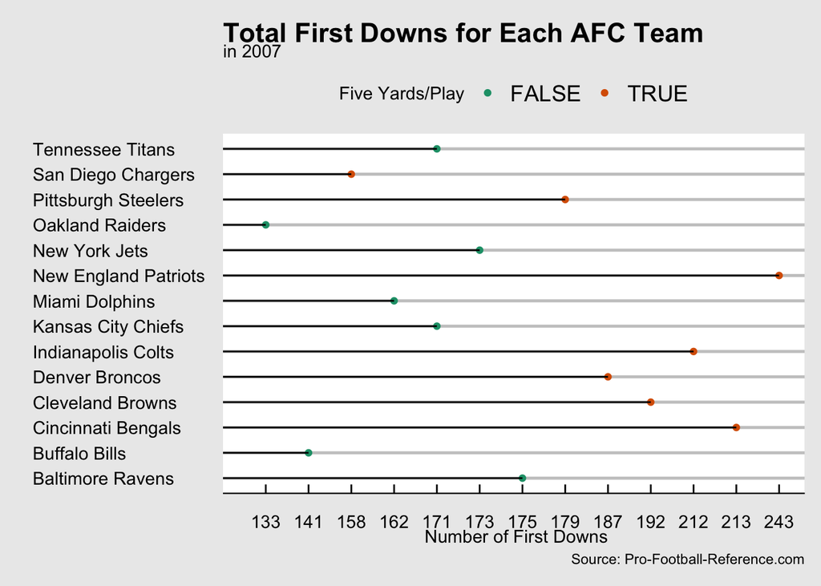

```r
standings%>%
  ggplot(data = sportsref_download_AFC, mapping = aes( x = ...2, y = ...17)) + geom_point(aes(color = ...7>=5)) + labs (x = "", y = " Number of First Downs", caption = "Source: Pro-Football-Reference.com") + labs(title = "Total First Downs for Each AFC Team ", subtitle = "in 2007", col = "Five Yards/Play") + coord_flip()  + theme_economist_white() + scale_color_brewer(palette = "Dark2") + geom_segment( aes(x=...2, xend=...2, y=0, yend=...17))
```

The graph above show the total number of first downs in the 2007 season for each team in the AFC. It is then separated by teams that had an average that is greater than or equal 5 yards per play. For those that are unfamiliar with how yards and downs work in football (although I’m sure if you’ve gotten this far, you likely know), a team has 4 chances, or “downs”, to advance the football 10 yards, if they do so, then it becomes a first down, and the goal is to continue to get first downs until the team can score a touchdown or kick a field goal. If the team does not move the football 10 yards in 4 downs (often 3, but that is an analysis for another time), then they return the ball to the other team.

Therefore, having an average of 5+ yards per play is important to scoring, and ultimately winning the game. Referring back the previous graph, over half of the AFC teams to have 5+ yards per play made it to the playoffs in the 2007 season. So its certainly an important statistic, one that the Patriots ruled once again, coming in first with a 6.2 average. This is a big driver of how the Patriots had the most number of 1st downs in the season. The more first downs a team has, the better chance of scoring, the better chance of scoring, there is a better chance of winning. And the Patriots did just that…16 times.

[figure not shown]

Tom Brady and Randy Moss, image source : sportscasting.com

### Defense Wins Championships

Despite a glorious 16 game winning streak, the 2008 Super Bowl was not the ideal place to it. Don’t forget that in 2007 the Patriots had the best offense (15.9), and the sixth best defense (4.2). Perhaps the old football adage of “defense wins championships” is true after all….or maybe not…

The New York Giants were the team to defeat the Patriots in the Super Bowl that year. Shockingly, the Giants only had a SRS of 3.3 (yes that is THREE POINT THREE) with a 2.8 offense rating, and a 0.4 defensive rating. The final score of the game was 17-14.

I’m told the game was tight, but I still refuse to watch.

While it can be easy to look at statistics and think "what the h*ll happened?" its important to remember that the Super Bowl is arguably the hardest championship game to win across every sport. One call, play, or injury could change the game. Football is so variable.

Thank you for reading.

**BONUS** A few neat stats from the 2008 Super Bowl:

- Tom Brady thew 0 interceptions
- There were 0 defensive touchdowns from either team
- Laurence Maroney (rushing) and Randy Moss (receiving) each scoreed a touchdown for NE
- Rodney Harrison had 12 tackles, the most for either team
- I was exactly 2096 days old!